# Capstone_Group_13 (2)

```python
from google.colab import drive
drive.mount('/content/drive')
```

Importing Libraries

```python
import numpy as np
import pandas as pd
import seaborn as sns
from matplotlib import pyplot as plt
%matplotlib inline

from sklearn.preprocessing import LabelEncoder

from sklearn.model_selection import train_test_split, cross_val_score

from sklearn.linear_model import LogisticRegression
from sklearn.neighbors import KNeighborsClassifier
from sklearn.svm import SVC
from sklearn.tree import DecisionTreeClassifier
from sklearn.ensemble import RandomForestClassifier, BaggingClassifier, AdaBoostClassifier, GradientBoostingClassifier

from sklearn.metrics import classification_report, confusion_matrix

import nltk
nltk.download('stopwords')
nltk.download('wordnet')    # loading the wordnet module that is used in stemming
nltk.download('averaged_perceptron_tagger')
nltk.download('punkt')

from nltk.stem.porter import PorterStemmer

from nltk.corpus import stopwords, wordnet
from nltk.tokenize import word_tokenize
import string
from nltk import tokenize, stem
from tensorflow.keras.preprocessing.text import Tokenizer

import re
import string
from nltk.probability import FreqDist
from nltk.util import ngrams
from nltk.tokenize import word_tokenize
from nltk.stem import WordNetLemmatizer

from string import punctuation
from wordcloud import STOPWORDS
from textblob import TextBlob

from sklearn.feature_extraction.text import CountVectorizer
from sklearn.feature_extraction.text import TfidfVectorizer
from gensim.models import Word2Vec


from keras.callbacks import EarlyStopping, ModelCheckpoint


from tensorflow.keras.utils import plot_model

import warnings
warnings.filterwarnings('ignore')
```

```python
path = '/content/drive/MyDrive/csv files/idbs.xlsx'
df = pd.read_excel(path)
# A quick look at the data
df.head(10)
```

|  | Unnamed: 0 | Data | Countries | Local | Industry Sector | Accident Level | Potential Accident Level | Genre | Employee or Third Party | Critical Risk | Description |
| --- | --- | --- | --- | --- | --- | --- | --- | --- | --- | --- | --- |
| 0 | 0 | 2016-01-01 | Country_01 | Local_01 | Mining | I | IV | Male | Third Party | Pressed | While removing the drill rod of the Jumbo 08 f... |
| 1 | 1 | 2016-01-02 | Country_02 | Local_02 | Mining | I | IV | Male | Employee | Pressurized Systems | During the activation of a sodium sulphide pum... |
| 2 | 2 | 2016-01-06 | Country_01 | Local_03 | Mining | I | III | Male | Third Party (Remote) | Manual Tools | In the sub-station MILPO located at level +170... |
| 3 | 3 | 2016-01-08 | Country_01 | Local_04 | Mining | I | I | Male | Third Party | Others | Being 9:45 am. approximately in the Nv. 1880 C... |
| 4 | 4 | 2016-01-10 | Country_01 | Local_04 | Mining | IV | IV | Male | Third Party | Others | Approximately at 11:45 a.m. in circumstances t... |
| 5 | 5 | 2016-01-12 | Country_02 | Local_05 | Metals | I | III | Male | Third Party (Remote) | Pressurized Systems | During the unloading operation of the ustulado... |
| 6 | 6 | 2016-01-16 | Country_02 | Local_05 | Metals | I | III | Male | Employee | Fall prevention (same level) | The collaborator reports that he was on street... |
| 7 | 7 | 2016-01-17 | Country_01 | Local_04 | Mining | I | III | Male | Third Party | Pressed | At approximately 04:50 p.m., when the mechanic... |
| 8 | 8 | 2016-01-19 | Country_02 | Local_02 | Mining | I | IV | Male | Third Party (Remote) | Others | Employee was sitting in the resting area at le... |
| 9 | 9 | 2016-01-26 | Country_01 | Local_06 | Metals | I | II | Male | Third Party | Chemical substances | At the moment the forklift operator went to ma... |

```python
# Drop irrelevant column Unnamed:0

df = df.drop(df.columns[0], axis=1)
df.head(10)
```

|  | Data | Countries | Local | Industry Sector | Accident Level | Potential Accident Level | Genre | Employee or Third Party | Critical Risk | Description |
| --- | --- | --- | --- | --- | --- | --- | --- | --- | --- | --- |
| 0 | 2016-01-01 | Country_01 | Local_01 | Mining | I | IV | Male | Third Party | Pressed | While removing the drill rod of the Jumbo 08 f... |
| 1 | 2016-01-02 | Country_02 | Local_02 | Mining | I | IV | Male | Employee | Pressurized Systems | During the activation of a sodium sulphide pum... |
| 2 | 2016-01-06 | Country_01 | Local_03 | Mining | I | III | Male | Third Party (Remote) | Manual Tools | In the sub-station MILPO located at level +170... |
| 3 | 2016-01-08 | Country_01 | Local_04 | Mining | I | I | Male | Third Party | Others | Being 9:45 am. approximately in the Nv. 1880 C... |
| 4 | 2016-01-10 | Country_01 | Local_04 | Mining | IV | IV | Male | Third Party | Others | Approximately at 11:45 a.m. in circumstances t... |
| 5 | 2016-01-12 | Country_02 | Local_05 | Metals | I | III | Male | Third Party (Remote) | Pressurized Systems | During the unloading operation of the ustulado... |
| 6 | 2016-01-16 | Country_02 | Local_05 | Metals | I | III | Male | Employee | Fall prevention (same level) | The collaborator reports that he was on street... |
| 7 | 2016-01-17 | Country_01 | Local_04 | Mining | I | III | Male | Third Party | Pressed | At approximately 04:50 p.m., when the mechanic... |
| 8 | 2016-01-19 | Country_02 | Local_02 | Mining | I | IV | Male | Third Party (Remote) | Others | Employee was sitting in the resting area at le... |
| 9 | 2016-01-26 | Country_01 | Local_06 | Metals | I | II | Male | Third Party | Chemical substances | At the moment the forklift operator went to ma... |

```python
# Rename the columns in a correct fashion
df.rename(columns = { 'Data' : 'Date',
                      'Industry Sector' : 'Industry_Sector',
                      'Accident Level': 'Accident_Level',
                      'Countries' : 'Country',
                      'Genre' : 'Gender',
                      'Potential Accident Level' : 'Potential_Accident_Level',
                      'Employee or Third Party' : 'Employee_Type',
                      'Critical Risk' : 'Critical_Risk'}, inplace = True)
```

```python
df.info()
```

```
<class 'pandas.core.frame.DataFrame'>
RangeIndex: 425 entries, 0 to 424
Data columns (total 10 columns):
 #   Column                    Non-Null Count  Dtype
---  ------                    --------------  -----
 0   Date                      425 non-null    datetime64[ns]
 1   Country                   425 non-null    object
 2   Local                     425 non-null    object
 3   Industry_Sector           425 non-null    object
 4   Accident_Level            425 non-null    object
 5   Potential_Accident_Level  425 non-null    object
 6   Gender                    425 non-null    object
 7   Employee_Type             425 non-null    object
 8   Critical_Risk             425 non-null    object
 9   Description               425 non-null    object
dtypes: datetime64[ns](1), object(9)
memory usage: 33.3+ KB
```

```python
df.shape
```

```
(425, 10)
```

```python
df.isnull()
```

|  | Date | Country | Local | Industry_Sector | Accident_Level | Potential_Accident_Level | Gender | Employee_Type | Critical_Risk | Description |
| --- | --- | --- | --- | --- | --- | --- | --- | --- | --- | --- |
| 0 | False | False | False | False | False | False | False | False | False | False |
| 1 | False | False | False | False | False | False | False | False | False | False |
| 2 | False | False | False | False | False | False | False | False | False | False |
| 3 | False | False | False | False | False | False | False | False | False | False |
| 4 | False | False | False | False | False | False | False | False | False | False |
| ... | ... | ... | ... | ... | ... | ... | ... | ... | ... | ... |
| 420 | False | False | False | False | False | False | False | False | False | False |
| 421 | False | False | False | False | False | False | False | False | False | False |
| 422 | False | False | False | False | False | False | False | False | False | False |
| 423 | False | False | False | False | False | False | False | False | False | False |
| 424 | False | False | False | False | False | False | False | False | False | False |

425 rows × 10 columns

```python
df.nunique().values
```

```
array([287,   3,  12,   3,   5,   6,   2,   3,  33, 411])
```

```python
df.duplicated().sum()
```

```
7
```

```python
df[df.duplicated()]
```

|  | Date | Country | Local | Industry_Sector | Accident_Level | Potential_Accident_Level | Gender | Employee_Type | Critical_Risk | Description |
| --- | --- | --- | --- | --- | --- | --- | --- | --- | --- | --- |
| 77 | 2016-04-01 | Country_01 | Local_01 | Mining | I | V | Male | Third Party (Remote) | Others | In circumstances that two workers of the Abrat... |
| 262 | 2016-12-01 | Country_01 | Local_03 | Mining | I | IV | Male | Employee | Others | During the activity of chuteo of ore in hopper... |
| 303 | 2017-01-21 | Country_02 | Local_02 | Mining | I | I | Male | Third Party (Remote) | Others | Employees engaged in the removal of material f... |
| 345 | 2017-03-02 | Country_03 | Local_10 | Others | I | I | Male | Third Party | Venomous Animals | On 02/03/17 during the soil sampling in the re... |
| 346 | 2017-03-02 | Country_03 | Local_10 | Others | I | I | Male | Third Party | Venomous Animals | On 02/03/17 during the soil sampling in the re... |
| 355 | 2017-03-15 | Country_03 | Local_10 | Others | I | I | Male | Third Party | Venomous Animals | Team of the VMS Project performed soil collect... |
| 397 | 2017-05-23 | Country_01 | Local_04 | Mining | I | IV | Male | Third Party | Projection of fragments | In moments when the 02 collaborators carried o... |

```python
df.drop_duplicates(inplace=True)
```

```python
df.shape
```

```
(418, 10)
```

```python
df.nunique().values
```

```
array([287,   3,  12,   3,   5,   6,   2,   3,  33, 411])
```

Insights:

```python
df.duplicated(subset=['Description'],keep=False).sum()
df[df.duplicated(subset=['Description'],keep=False)].sort_values(by='Description')
```

|  | Date | Country | Local | Industry_Sector | Accident_Level | Potential_Accident_Level | Gender | Employee_Type | Critical_Risk | Description |
| --- | --- | --- | --- | --- | --- | --- | --- | --- | --- | --- |
| 166 | 2016-07-07 | Country_01 | Local_03 | Mining | IV | V | Male | Third Party | Others | At moments when the MAPERU truck of plate F1T ... |
| 167 | 2016-07-07 | Country_01 | Local_03 | Mining | I | IV | Male | Third Party | Others | At moments when the MAPERU truck of plate F1T ... |
| 261 | 2016-12-01 | Country_01 | Local_03 | Mining | I | IV | Male | Employee | Others | During the activity of chuteo of ore in hopper... |
| 263 | 2016-12-01 | Country_01 | Local_03 | Mining | I | IV | Male | Third Party | Others | During the activity of chuteo of ore in hopper... |
| 412 | 2017-06-20 | Country_01 | Local_01 | Mining | I | IV | Male | Employee | Others | In circumstance, the AHK-903 license plate (Em... |
| 413 | 2017-06-20 | Country_01 | Local_01 | Mining | I | IV | Male | Third Party | Others | In circumstance, the AHK-903 license plate (Em... |
| 130 | 2016-05-26 | Country_03 | Local_10 | Others | I | I | Male | Third Party | Bees | In the geological reconnaissance activity, in ... |
| 131 | 2016-05-26 | Country_03 | Local_10 | Others | I | I | Male | Employee | Others | In the geological reconnaissance activity, in ... |
| 143 | 2016-06-08 | Country_03 | Local_10 | Others | I | I | Male | Third Party | Bees | Project of Vazante that carried out sediment c... |
| 144 | 2016-06-08 | Country_03 | Local_10 | Others | I | I | Male | Third Party | Others | Project of Vazante that carried out sediment c... |
| 387 | 2017-05-06 | Country_02 | Local_07 | Mining | IV | V | Male | Employee | Projection | The employees Márcio and Sérgio performed the ... |
| 388 | 2017-05-06 | Country_02 | Local_07 | Mining | II | V | Male | Employee | Projection | The employees Márcio and Sérgio performed the ... |
| 37 | 2016-02-24 | Country_02 | Local_07 | Mining | I | V | Male | Employee | Others | When starting the activity of removing a coil ... |
| 38 | 2016-02-24 | Country_02 | Local_07 | Mining | I | V | Female | Third Party | Others | When starting the activity of removing a coil ... |

```python
df.drop_duplicates(subset=['Description'], keep='first', inplace=True)
print('shape of the data after eliminating duplicates is:', df.shape)
```

```
shape of the data after eliminating duplicates is: (411, 10)
```

Now we can see that after removing the duplicates the count of unique values in the description column and the total number of datapoints in the dataset is matching.

**EDA**

```python
data_shape = df.shape
print('Data set contains {} number of rows and {} number of columns' .format(data_shape[0], data_shape[1]))
```

```
Data set contains 411 number of rows and 10 number of columns
```

```python
df.info()
```

```
<class 'pandas.core.frame.DataFrame'>
Index: 411 entries, 0 to 424
Data columns (total 10 columns):
 #   Column                    Non-Null Count  Dtype
---  ------                    --------------  -----
 0   Date                      411 non-null    datetime64[ns]
 1   Country                   411 non-null    object
 2   Local                     411 non-null    object
 3   Industry_Sector           411 non-null    object
 4   Accident_Level            411 non-null    object
 5   Potential_Accident_Level  411 non-null    object
 6   Gender                    411 non-null    object
 7   Employee_Type             411 non-null    object
 8   Critical_Risk             411 non-null    object
 9   Description               411 non-null    object
dtypes: datetime64[ns](1), object(9)
memory usage: 35.3+ KB
```

```python
# Looping through all the columns in the dataframe and checking counts of unique values.
for col in df.columns:
    if (col!='Description') and (col!='Date'):
        print(df[col].value_counts())
        print('*'*50)
```

```
Country
Country_01    245
Country_02    127
Country_03     39
Name: count, dtype: int64
Local
Local_03    87
Local_05    59
Local_01    55
Local_04    55
Local_06    46
Local_10    39
Local_08    27
Local_02    23
Local_07    12
Local_12     4
Local_09     2
Local_11     2
Name: count, dtype: int64
Industry_Sector
Mining    232
Metals    134
Others     45
Name: count, dtype: int64
Accident_Level
I      303
II      39
III     31
IV      30
V        8
Name: count, dtype: int64
Potential_Accident_Level
IV     138
III    106
II      95
I       43
V       28
VI       1
Name: count, dtype: int64
Gender
```

[output cut: 28 more lines]

```
Machine Protection                             2
Electrical Shock                               2
Poll                                           1
Individual protection equipment                1
Projection/Manual Tools                        1
Burn                                           1
Electrical installation                        1
Projection/Choco                               1
Projection/Burning                             1
Plates                                         1
Confined space                                 1
Traffic                                        1
\nNot applicable                               1
Projection of fragments                        1
Name: count, dtype: int64
```

1. There are total of Three countries and Twelve plants/cities overall,
2. Three type of Industry sectors exist namely: 'Mining', 'Metals' and Others.
3. Five type of accident levels (1 to 5) are present.
4. Six type of Potential Accident Levels (1 to 6) and we see that there is only
5. one value registered under 'Accident level 6' and it can be replaced to level 5 to reduce the complexity
6. Three type of employee types namely: 'Third Party', 'Employee', 'Third Party(Remote)
7. There are about 33 critical risks in which more than half of the incidents fall under the 'Others' category, these entries have been changed to 'Others' as part of the anonymization process.
8. Level VI accident is having only one incident hence it can be replaced  
   with Level V as it is more closer one

```python
df['Potential_Accident_Level'] = df['Potential_Accident_Level'].replace('VI', 'V')
```

# Visualization

## Univariate Analysis

```python
# Creating a function to make univariate plots for analysis
import matplotlib.pyplot as plt
import seaborn as sns
def plot(df,col, title, palette, edgecolor):

    if col not in df.columns:
        print(f"Column '{col}' not found in the dataframe.")
        return

    plt.figure(figsize=(20, 15))

    # Count Plot
    plt.subplot(2, 2, 1)
    sns.countplot(df[col], palette=palette, edgecolor=edgecolor, order=df[col].value_counts().index, alpha=1.0, saturation=1)
    plt.title(f'{title} - Count Plot')

    # Pie Chart
    plt.subplot(2, 2, 2)
    plt.pie(df[col].value_counts(), autopct="%.2f", labels=df[col].value_counts().index, shadow=True,
            explode=[0.1] * len(df[col].value_counts().index), startangle=-135)
    plt.title(f'{title} - Pie Chart')

    plt.show()
```

Industry Sector

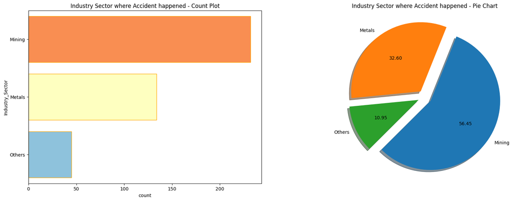

```python
plot(df,'Industry_Sector', 'Industry Sector where Accident happened', 'RdYlBu', 'orange')
```

- It clearly indicates that mining industries witness more accidents.
- We can say that the number of accidents in Mining Industry is considerably more than that in the Metal Industry, therefore mining job is more risky than the latter.

Gender

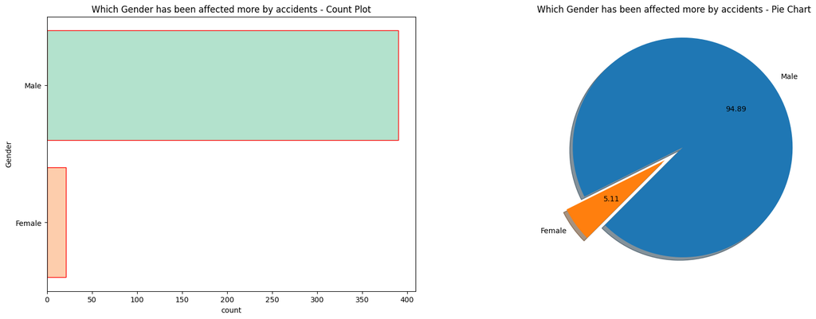

```python
plot(df,'Gender', 'Which Gender has been affected more by accidents', 'Pastel2', 'red')
```

- As a characteristic of the industry, the proportion of Men employees is very high (94.89%) compare to female proportion 5.11%
- The dataset is biased towards Male employees.

Employee Type

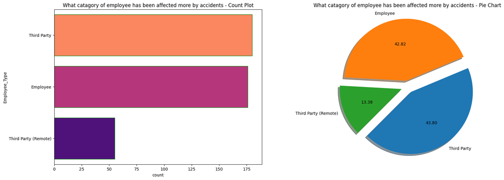

```python
plot(df,'Employee_Type', 'What catagory of employee has been affected more by accidents', 'magma_r', 'green')
```

Total number of Direct Employees and Third party employees are almost same, However, Third party remote employees are less in number.

Country

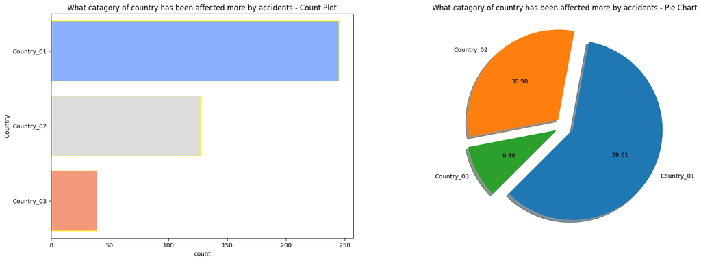

```python
plot(df,'Country', 'What catagory of country has been affected more by accidents', 'coolwarm', 'yellow')
```

- Country_01 shows largest proportion of accidents

Local

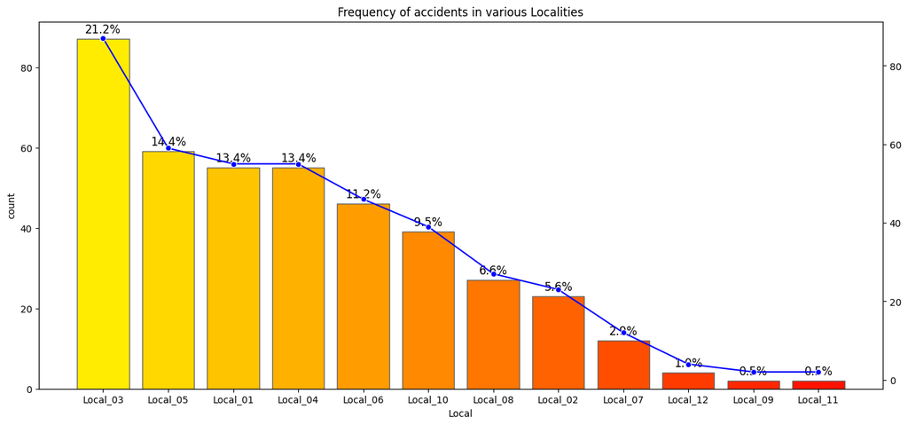

```python
plt.figure(figsize=(16, 7))

# Count Plot
ax = sns.countplot(x=df['Local'], order=df['Local'].value_counts().index, palette='autumn_r', edgecolor='.4', saturation=1)

# Line Plot (secondary y-axis)
ax2 = ax.twinx()
sns.lineplot(x=df['Local'].value_counts().index, y=df['Local'].value_counts().values, ax=ax2, color='b', marker='o')

plt.title('Frequency of accidents in various Localities')
plt.xticks(rotation='vertical')

# Adding annotations
total = sum(df['Local'].value_counts())
for p in ax.patches:
    ax.annotate(f'{100 * p.get_height() / total:.1f}%',
                (p.get_x() + p.get_width() / 2., p.get_height()),
                ha='center', va='center',
                size=12,
                xytext=(0, 10),
                textcoords='offset points')

plt.show()
```

Local_03 has recorded maximum number of accidents which is approx 21% of all the plants in the country. This is followed by Local-05, Local-01 and so on.

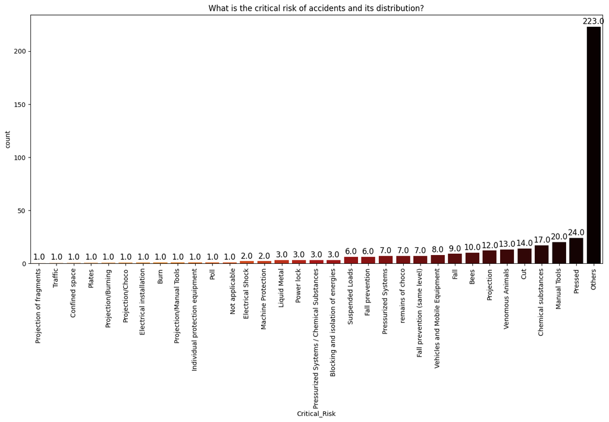

```python
plt.figure(figsize=(16, 7))

# Count Plot
ax = sns.countplot(x=df['Critical_Risk'], order=df['Critical_Risk'].value_counts().sort_values(ascending=True).index, palette='gist_heat_r')
plt.title('What is the critical risk of accidents and its distribution?')
plt.xticks(rotation='vertical')

# Adding annotations
total = sum(df['Critical_Risk'].value_counts())
for p in ax.patches:
    ax.annotate('{}'.format(p.get_height()),
                (p.get_x() + p.get_width() / 2., p.get_height()),
                ha='center', va='center',
                size=12,
                xytext=(0, 8),
                textcoords='offset points')

plt.show()
```

Most of the Critical Risks are classified as 'Others' that is almost 50% of the dataset, hence there are too many risks need to be classified precisely. This is followed by Pressed, Manual tools, Chemical substances, Cut etc..

Accident Level

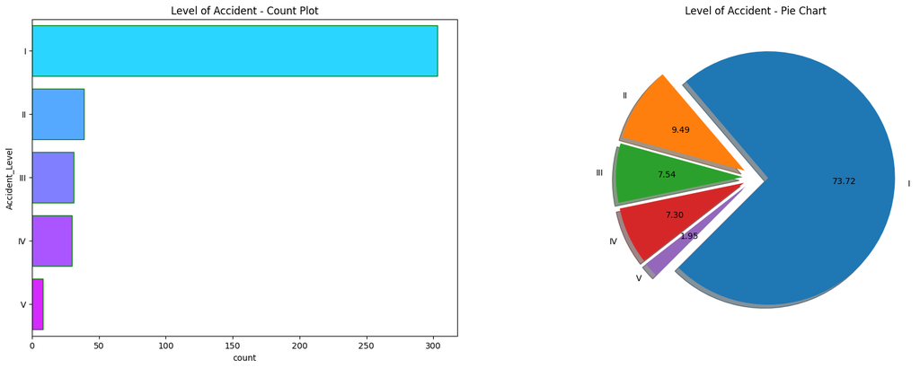

```python
plot(df,'Accident_Level', 'Level of Accident', 'cool', 'green')
```

- Level I signifies not severe and V signifies very severe.
- Accidents with the level I are most common. These are due to small misses, like people forgot their PPE, or they dropped a tool, etc.

Potential Accident Level

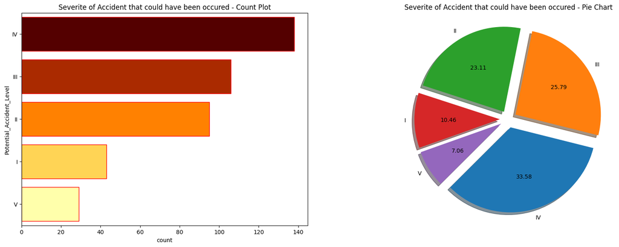

```python
plot(df,'Potential_Accident_Level', 'Severite of Accident that could have been occured', 'afmhot', 'red')
```

- Potential accident level indicates how severe the accident would been due to other factors involved in the accidents.
- Potential accident level IV has the highest count and signifies the moderate severity of accidents.
- We have to check the correlation of this Potential Accident level and Accident level along with the industry sector.

Bivariate Analysis

- On target column

Potential Accident level counts by Country

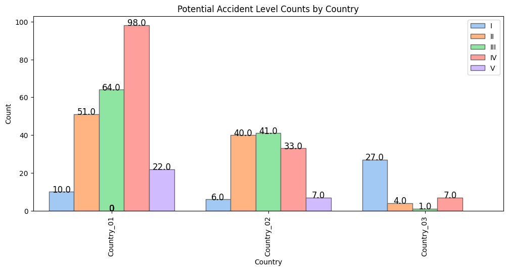

```python
plt.figure(figsize=(12, 5))

# Count Plot with Hue
ax = sns.countplot(data=df, x='Country', hue='Potential_Accident_Level',
                   hue_order=df['Potential_Accident_Level'].value_counts().sort_index().index,
                   palette='pastel', edgecolor='.4', saturation=1)

# Adding annotations
for p in ax.patches:
    height = p.get_height()
    ax.annotate(f'{height}',
                (p.get_x() + p.get_width() / 2., height),
                ha='center', va='center',
                size=12,
                xytext=(0, 3),
                textcoords='offset points')

plt.title('Potential Accident Level Counts by Country')
plt.ylabel('Count')
plt.legend(loc='upper right')
plt.xticks(rotation='vertical')
plt.show()
```

- Country_01 has more number of severe accidents especially Level IV
- Country_02 has moderate accidents across all the levels
- Country_03 'level I' accidents counts is more compared to country_01 and country_02 but less severe accidents.

Potential Accident level counts by Local

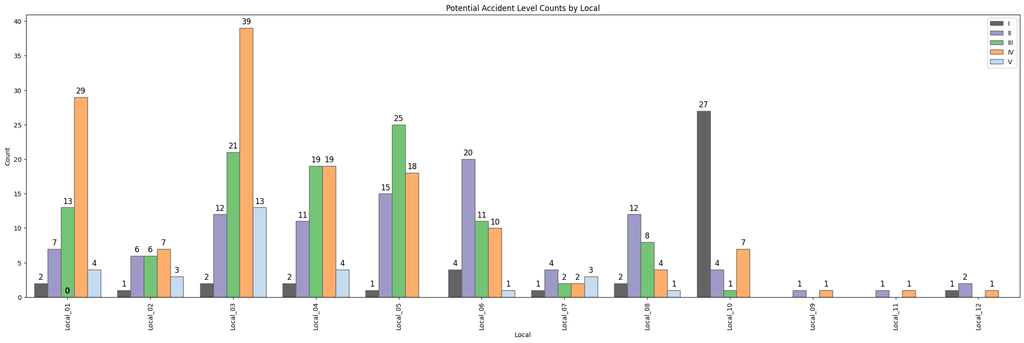

```python
plt.figure(figsize=(28, 8))

# Count Plot with Hue
ax = sns.countplot(data=df, x='Local', hue='Potential_Accident_Level',
                   hue_order=df['Potential_Accident_Level'].value_counts().sort_index().index,
                   palette='tab20c_r', edgecolor='.4', saturation=1)

# Adding annotations
for p in ax.patches:
    height = p.get_height()
    ax.annotate(f'{height:.0f}',
                (p.get_x() + p.get_width() / 2., height),
                ha='center', va='bottom',
                size=12,
                xytext=(0, 3),
                textcoords='offset points')

plt.title('Potential Accident Level Counts by Local')
plt.ylabel('Count')
plt.legend(loc='upper right')
plt.xticks(rotation='vertical')
plt.show()
```

- Local_03 (which also belongs to Country_01) is where most of the accidents happen

Potential Accident level counts by Industry Sector

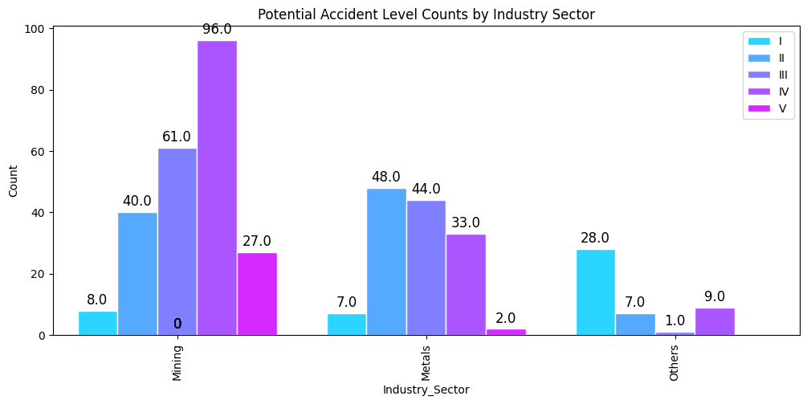

```python
plt.figure(figsize=(12, 5))

# Count Plot with Hue
ax = sns.countplot(data=df, x='Industry_Sector', hue='Potential_Accident_Level',
                   hue_order=df['Potential_Accident_Level'].value_counts().sort_index().index,
                   palette='cool', edgecolor='1.0', saturation=1)

# Adding annotations
for p in ax.patches:
    height = p.get_height()
    ax.annotate(f'{height}',
                (p.get_x() + p.get_width() / 2., height),
                ha='center', va='bottom',
                size=12,
                xytext=(0, 3),
                textcoords='offset points')

plt.title('Potential Accident Level Counts by Industry Sector')
plt.ylabel('Count')
plt.legend(loc='upper right')
plt.xticks(rotation='vertical')
plt.show()
```

Potential Accident level counts by Employee Type

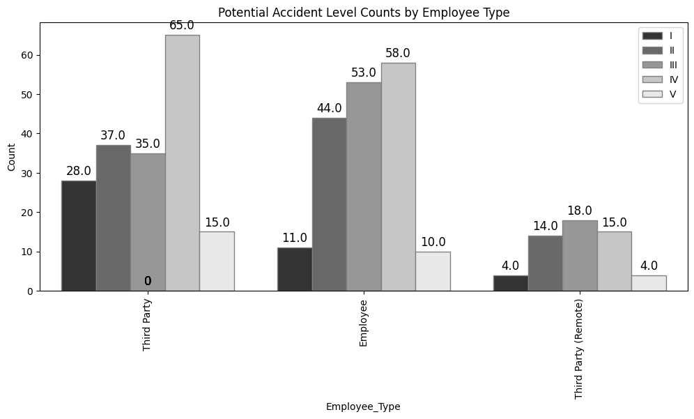

```python
plt.figure(figsize=(12, 5))

# Count Plot with Hue
ax = sns.countplot(data=df, x='Employee_Type', hue='Potential_Accident_Level',
                   hue_order=df['Potential_Accident_Level'].value_counts().sort_index().index,
                   palette='Greys_r', edgecolor='.5', saturation=1)

# Adding annotations
for p in ax.patches:
    height = p.get_height()
    ax.annotate(f'{height}',
                (p.get_x() + p.get_width() / 2., height),
                ha='center', va='bottom',
                size=12,
                xytext=(0, 3),
                textcoords='offset points')

plt.title('Potential Accident Level Counts by Employee Type')
plt.ylabel('Count')
plt.legend(loc='upper right')
plt.xticks(rotation='vertical')  # Rotate x-tick labels if needed for readability
plt.show()
```

- Third Party Employees are more involved in Accidents
- We can observe that apart from Accident_Level_1 the people are also facing severe accidents (Accident_Level_IV) in the industry.

Potential Accident level counts by Critical Risk

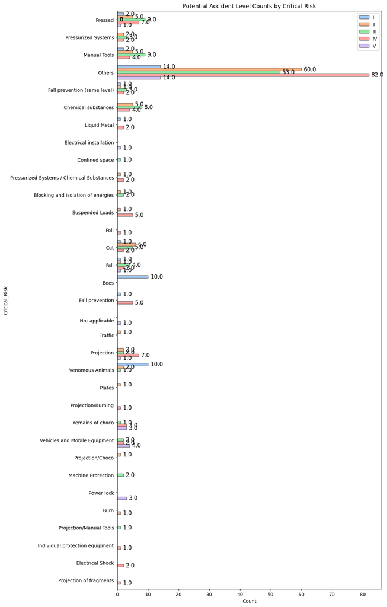

```python
plt.figure(figsize=(10, 22))

# Horizontal Count Plot with Hue
ax = sns.countplot(y='Critical_Risk', hue='Potential_Accident_Level',
                   data=df, hue_order=df['Potential_Accident_Level'].value_counts().sort_index().index,
                   palette='pastel', edgecolor='.4', saturation=1)

# Adding annotations
for p in ax.patches:
    width = p.get_width()
    ax.annotate(f'{width}',
                (width, p.get_y() + p.get_height() / 2.),
                ha='left', va='center',
                size=12,
                xytext=(5, 0),
                textcoords='offset points')

plt.title('Potential Accident Level Counts by Critical Risk')
plt.xlabel('Count')
plt.legend(loc='upper right')
plt.show()
```

Potential Accident level counts with respect to Gender¶ Since Gender is more biased towards male, we are taking ratio count with respect to other variables

```python
df1 = df.groupby(['Gender','Potential_Accident_Level'])['Potential_Accident_Level'].count()

# 1.unstack() Function in dataframe unstacks the row to columns.
# 2.applying the row total and taking the ratio of male and female employees.
# 3.resetting the index

df1 = df1.unstack().apply(lambda x: round(x / x.sum()*100), axis=1).reset_index()
df1 = pd.melt(df1, ['Gender']).fillna(0) # melt() function unpivots a DataFrame from wide format to long format
df1
```

|  | Gender | Potential_Accident_Level | value |
| --- | --- | --- | --- |
| 0 | Female | I | 0.0 |
| 1 | Male | I | 11.0 |
| 2 | Female | II | 67.0 |
| 3 | Male | II | 21.0 |
| 4 | Female | III | 14.0 |
| 5 | Male | III | 26.0 |
| 6 | Female | IV | 19.0 |
| 7 | Male | IV | 34.0 |
| 8 | Female | V | 0.0 |
| 9 | Male | V | 7.0 |

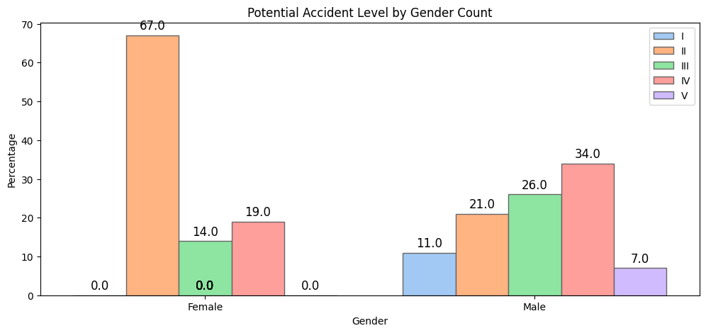

```python
plt.figure(figsize=(12, 5))

# Bar Plot with Hue
ax = sns.barplot(data=df1, x='Gender', y='value', hue='Potential_Accident_Level',
                 palette='pastel', edgecolor='.4', saturation=1)

# Adding annotations
for p in ax.patches:
    height = p.get_height()
    ax.annotate(f'{height:.1f}',
                (p.get_x() + p.get_width() / 2., height),
                ha='center', va='bottom',
                size=12,
                xytext=(0, 3),
                textcoords='offset points')

plt.title('Potential Accident Level by Gender Count')
plt.ylabel('Percentage')
plt.xlabel('Gender')
plt.legend(loc='upper right')
plt.show()
```

- Males are more involved in Severe Accidents whereas Females are suffering with less Servere ones (Level II specifically)

```python
# Getting the value counts of each of the columns
accident = df['Accident_Level'].value_counts()
potential = df['Potential_Accident_Level'].value_counts()

# Merging both values of the dataframe
acc_pot = pd.concat([accident, potential], axis=1,sort=False).fillna(0).reset_index()

# Need to melt down columns so that they can be treated as hue in plotting
acc_pot = pd.melt(acc_pot, ['index'], var_name='Accident type', value_name='count_Value')
acc_pot
```

|  | index | Accident type | count_Value |
| --- | --- | --- | --- |
| 0 | I | count | 303 |
| 1 | II | count | 39 |
| 2 | III | count | 31 |
| 3 | IV | count | 30 |
| 4 | V | count | 8 |
| 5 | I | count | 43 |
| 6 | II | count | 95 |
| 7 | III | count | 106 |
| 8 | IV | count | 138 |
| 9 | V | count | 29 |

- Notice there is a significant difference between the severity of an incident, and the potential severity of the incident.
- If the number of accidents increases, the potential accident level decreases
- There are high number of the Level 1 accidents.
- If the Accident level increases, the potential accident level also increases

Bivariate Analysis between the independent variables

Accidents Count by Country and Local

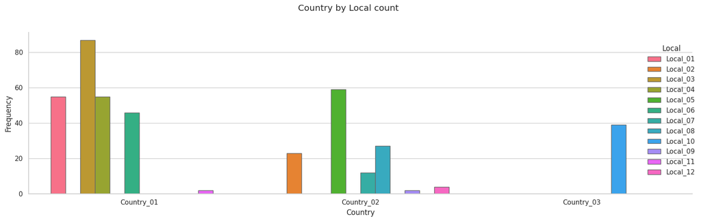

```python
sns.set(style="whitegrid")

# Creating the catplot directly without plt.figure
g = sns.catplot(data=df, kind='count', x='Country', hue='Local', height=5, aspect=3, edgecolor='.4', saturation=1)

# Adding title and adjusting labels
g.set_axis_labels("Country", "Frequency")
g.fig.suptitle('Country by Local count', y=1.02)

# Adjusting plot layout
plt.tight_layout()

plt.show()
```

Accidents Count by Industry_Sector and Local

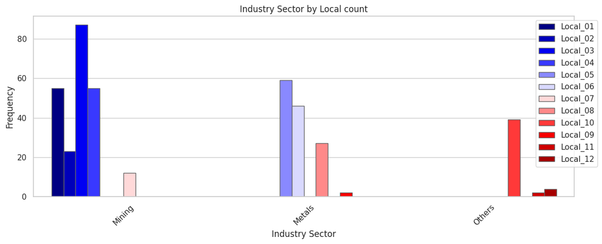

```python
plt.figure(figsize=(12, 5))
sns.countplot(data=df, x='Industry_Sector', hue='Local', edgecolor='.4', saturation=1, palette='seismic')
plt.title('Industry Sector by Local count')
plt.xlabel('Industry Sector')
plt.ylabel('Frequency')
plt.legend(loc='best', bbox_to_anchor=(1.05, 1))

plt.xticks(rotation=45)  # Rotate x labels for better readability
plt.tight_layout()  # Adjust layout to make room for the legend

plt.show()
```

It can be observed that Industry Sector depends on the Local area too.

- Local Area 1,2,3,4 and 7 belong to Mining Sector.
- Local Area 5,6,8 and 9 belong to Metal Sector.
- Local Area 10, 11 and 12 belong to Other Sectors.

Employeee type by Gender Count

**Since Gender is more biased towards male, we are taking ratio count with respect to other variables**

```python
# Filtering the dataframe by Gender and Employee type and taking the count.
df1 = df.groupby(['Gender','Employee_Type'])['Employee_Type'].count()

# 1.unstack() Function in dataframe unstacks the row to columns.
# 2.applying the row total and taking the ratio of male and female employees.
# 3.resetting the index

df1 = df1.unstack().apply(lambda x: round(x / x.sum()*100), axis=1).reset_index()
df1 = pd.melt(df1, ['Gender']) # melt() function unpivots a DataFrame from wide format to long format
df1
```

|  | Gender | Employee_Type | value |
| --- | --- | --- | --- |
| 0 | Female | Employee | 38.0 |
| 1 | Male | Employee | 43.0 |
| 2 | Female | Third Party | 38.0 |
| 3 | Male | Third Party | 44.0 |
| 4 | Female | Third Party (Remote) | 24.0 |
| 5 | Male | Third Party (Remote) | 13.0 |

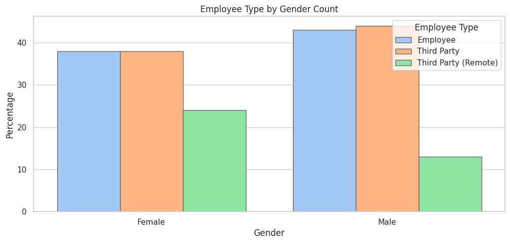

```python
plt.figure(figsize=(12, 5))
sns.barplot(data=df1, x='Gender', y='value', hue='Employee_Type', palette='pastel', edgecolor='.4', saturation=1)
plt.title('Employee Type by Gender Count')
plt.ylabel('Percentage')

plt.legend(title='Employee Type', loc='best')
plt.show()
```

Industry_Sector by Gender Count

```python
df1 = pd.melt(df.groupby(['Gender','Industry_Sector'])['Industry_Sector'].count().unstack().apply(lambda x: round(x / x.sum()*100), axis=1).reset_index(),['Gender'])
df1
```

|  | Gender | Industry_Sector | value |
| --- | --- | --- | --- |
| 0 | Female | Metals | 62.0 |
| 1 | Male | Metals | 31.0 |
| 2 | Female | Mining | 19.0 |
| 3 | Male | Mining | 58.0 |
| 4 | Female | Others | 19.0 |
| 5 | Male | Others | 11.0 |

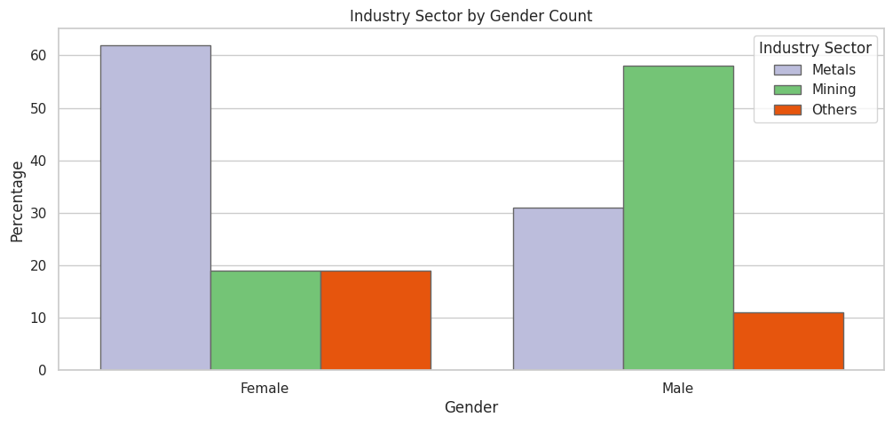

```python
plt.figure(figsize=(12, 5))
sns.barplot(data=df1, x='Gender', y='value', hue='Industry_Sector', palette='tab20c_r', edgecolor='.4', saturation=1)
plt.title('Industry Sector by Gender Count')
plt.ylabel('Percentage')
plt.xlabel('Gender')
plt.legend(title='Industry Sector', loc='best')

plt.show()
```

- There is a major diferrence in mining and metals industries within males and females
- We can observe the distinct safety levels by the industry sectors towards male and female

Critical Risk counts by Gender

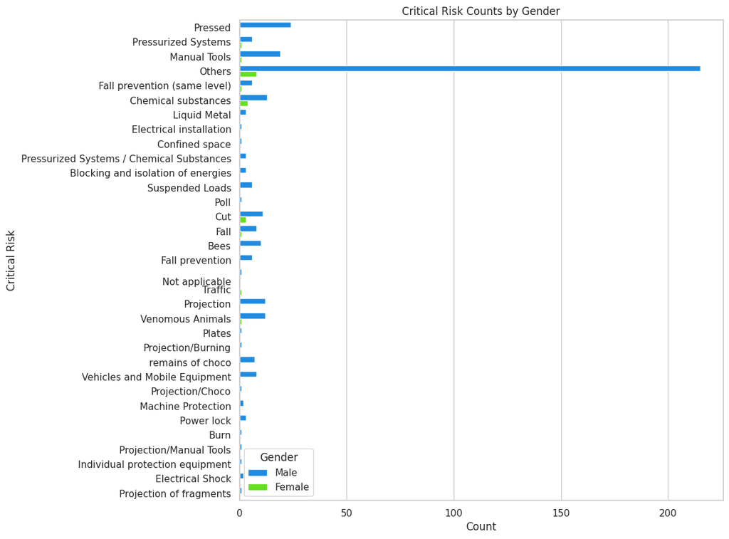

```python
plt.figure(figsize=(10, 10))
sns.countplot(y='Critical_Risk', hue='Gender', data=df, palette='gist_rainbow_r')
plt.title('Critical Risk Counts by Gender')
plt.xlabel('Count')
plt.ylabel('Critical Risk')
plt.legend(title='Gender', loc='best')

plt.show()
```

- There are some amount of females who involved in Critical Risks such as Chemical Substances, Cut, Fall other than Others category
- As dataset has more number of male data points, the plot bars tends to increase on the same class.

Correlation **plot**

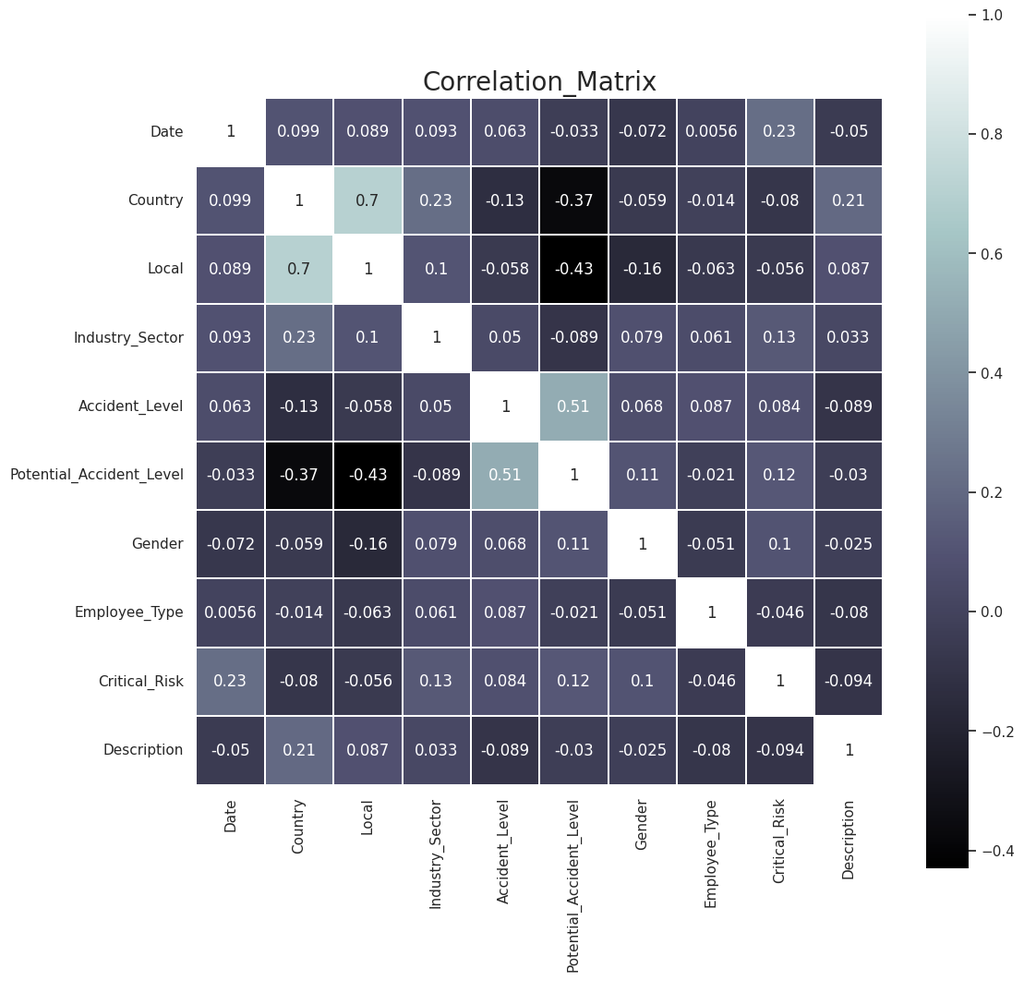

```python
# Correlation
le = LabelEncoder()
df_enc = df.apply(le.fit_transform)

plt.figure(figsize=(12,12))
plt.title('Correlation_Matrix', fontsize=20)
sns.heatmap(df_enc.corr(), square=True, cmap='bone', annot=True, linewidth=0.2);
```

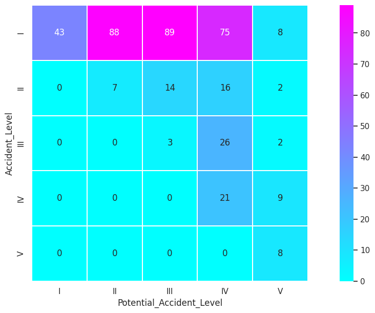

```python
# Count of Accidents grouped by Accident Level and Potential accident level
plt.figure(figsize = (16,7))
sns.heatmap(pd.crosstab(df.Accident_Level, df.Potential_Accident_Level), square=True, cmap='cool', annot=True, linewidth=0.1)
```

- There is a moderate correleation among the values of both variables.

```python
# Count of Critical Risks grouped by Industry sectors
df.pivot_table(index='Critical_Risk', columns='Industry_Sector', aggfunc='count').fillna(0)['Accident_Level'].T
```

| Critical_Risk Industry_Sector | \nNot applicable | Bees | Blocking and isolation of energies | Burn | Chemical substances | Confined space | Cut | Electrical Shock | Electrical installation | Fall | ... | Projection | Projection of fragments | Projection/Burning | Projection/Choco | Projection/Manual Tools | Suspended Loads | Traffic | Vehicles and Mobile Equipment | Venomous Animals | remains of choco |
| --- | --- | --- | --- | --- | --- | --- | --- | --- | --- | --- | --- | --- | --- | --- | --- | --- | --- | --- | --- | --- | --- |
| Metals | 1.0 | 0.0 | 3.0 | 1.0 | 15.0 | 1.0 | 10.0 | 0.0 | 0.0 | 2.0 | ... | 4.0 | 0.0 | 1.0 | 0.0 | 0.0 | 5.0 | 0.0 | 0.0 | 2.0 | 0.0 |
| Mining | 0.0 | 0.0 | 0.0 | 0.0 | 2.0 | 0.0 | 4.0 | 2.0 | 1.0 | 5.0 | ... | 8.0 | 1.0 | 0.0 | 0.0 | 1.0 | 1.0 | 0.0 | 8.0 | 1.0 | 7.0 |
| Others | 0.0 | 10.0 | 0.0 | 0.0 | 0.0 | 0.0 | 0.0 | 0.0 | 0.0 | 2.0 | ... | 0.0 | 0.0 | 0.0 | 1.0 | 0.0 | 0.0 | 1.0 | 0.0 | 10.0 | 0.0 |

3 rows × 33 columns

Data Preprocessing (NLP PREPROCESSING)

```python
df['Description'][0]
```

```
'While removing the drill rod of the Jumbo 08 for maintenance, the supervisor proceeds to loosen the support of the intermediate centralizer to facilitate the removal, seeing this the mechanic supports one end on the drill of the equipment to pull with both hands the bar and accelerate the removal f…
```

1. Removing Special Characteristics

```python
#Removing special characteristics

def remove_special_characters(text):
    # Defining the regex pattern to match non-alphanumeric characters
    pattern = '[^A-Za-z0-9]+'

    # Finding the specified pattern and replacing non-alphanumeric characters with a blank string
    new_text = ''.join(re.sub(pattern, ' ', text))

    return new_text
```

```python
df['cleaned_text'] = df['Description'].apply(remove_special_characters)
```

```python
df.loc[0:8,['Description','cleaned_text']]
```

|  | Description | cleaned_text |
| --- | --- | --- |
| 0 | While removing the drill rod of the Jumbo 08 f... | While removing the drill rod of the Jumbo 08 f... |
| 1 | During the activation of a sodium sulphide pum... | During the activation of a sodium sulphide pum... |
| 2 | In the sub-station MILPO located at level +170... | In the sub station MILPO located at level 170 ... |
| 3 | Being 9:45 am. approximately in the Nv. 1880 C... | Being 9 45 am approximately in the Nv 1880 CX ... |
| 4 | Approximately at 11:45 a.m. in circumstances t... | Approximately at 11 45 a m in circumstances th... |
| 5 | During the unloading operation of the ustulado... | During the unloading operation of the ustulado... |
| 6 | The collaborator reports that he was on street... | The collaborator reports that he was on street... |
| 7 | At approximately 04:50 p.m., when the mechanic... | At approximately 04 50 p m when the mechanic t... |
| 8 | Employee was sitting in the resting area at le... | Employee was sitting in the resting area at le... |

1. Lower Casing

```python
df['cleaned_text'] = df['cleaned_text'].str.lower()
```

```python
df.loc[0:5, ['Description','cleaned_text']]
```

|  | Description | cleaned_text |
| --- | --- | --- |
| 0 | While removing the drill rod of the Jumbo 08 f... | while removing the drill rod of the jumbo 08 f... |
| 1 | During the activation of a sodium sulphide pum... | during the activation of a sodium sulphide pum... |
| 2 | In the sub-station MILPO located at level +170... | in the sub station milpo located at level 170 ... |
| 3 | Being 9:45 am. approximately in the Nv. 1880 C... | being 9 45 am approximately in the nv 1880 cx ... |
| 4 | Approximately at 11:45 a.m. in circumstances t... | approximately at 11 45 a m in circumstances th... |
| 5 | During the unloading operation of the ustulado... | during the unloading operation of the ustulado... |

1. Removing any extra white space

```python
df['cleaned_text'] = df['cleaned_text'].str.strip()
```

```python
df.loc[0:3, ['Description','cleaned_text']]
```

|  | Description | cleaned_text |
| --- | --- | --- |
| 0 | While removing the drill rod of the Jumbo 08 f... | while removing the drill rod of the jumbo 08 f... |
| 1 | During the activation of a sodium sulphide pum... | during the activation of a sodium sulphide pum... |
| 2 | In the sub-station MILPO located at level +170... | in the sub station milpo located at level 170 ... |
| 3 | Being 9:45 am. approximately in the Nv. 1880 C... | being 9 45 am approximately in the nv 1880 cx ... |

1. Removing Stop words

```python
def remove_stopwords(text):
    # Split text into separate words
    words = text.split()

    # Removing English language stopwords
    new_text = ' '.join([word for word in words if word not in stopwords.words('english')])

    return new_text
```

```python
df['cleaned_text_without_stopwords'] = df['cleaned_text'].apply(remove_stopwords)
```

```python
df.loc[0:5,['cleaned_text','cleaned_text_without_stopwords']]
```

|  | cleaned_text | cleaned_text_without_stopwords |
| --- | --- | --- |
| 0 | while removing the drill rod of the jumbo 08 f... | removing drill rod jumbo 08 maintenance superv... |
| 1 | during the activation of a sodium sulphide pum... | activation sodium sulphide pump piping uncoupl... |
| 2 | in the sub station milpo located at level 170 ... | sub station milpo located level 170 collaborat... |
| 3 | being 9 45 am approximately in the nv 1880 cx ... | 9 45 approximately nv 1880 cx 695 ob7 personne... |
| 4 | approximately at 11 45 a m in circumstances th... | approximately 11 45 circumstances mechanics an... |
| 5 | during the unloading operation of the ustulado... | unloading operation ustulado bag need unclog d... |

1. Stemming

```python
ps = PorterStemmer()

def apply_porter_stemmer(text):
    # Split text into separate words
    words = text.split()

    # Applying the Porter Stemmer on every word of a message and joining the stemmed words back into a single string
    new_text = ' '.join([ps.stem(word) for word in words])

    return new_text
```

```python
df['final_cleaned_text'] = df['cleaned_text_without_stopwords'].apply(apply_porter_stemmer)
```

```python
df.loc[0:5,['cleaned_text_without_stopwords','final_cleaned_text']]
```

|  | cleaned_text_without_stopwords | final_cleaned_text |
| --- | --- | --- |
| 0 | removing drill rod jumbo 08 maintenance superv... | remov drill rod jumbo 08 mainten supervisor pr... |
| 1 | activation sodium sulphide pump piping uncoupl... | activ sodium sulphid pump pipe uncoupl sulfid ... |
| 2 | sub station milpo located level 170 collaborat... | sub station milpo locat level 170 collabor exc... |
| 3 | 9 45 approximately nv 1880 cx 695 ob7 personne... | 9 45 approxim nv 1880 cx 695 ob7 personnel beg... |
| 4 | approximately 11 45 circumstances mechanics an... | approxim 11 45 circumst mechan anthoni group l... |
| 5 | unloading operation ustulado bag need unclog d... | unload oper ustulado bag need unclog discharg ... |

1. Lemmatization

```python
import nltk
from nltk.corpus import wordnet
from nltk.stem import WordNetLemmatizer

lemmatizer = WordNetLemmatizer()

# Function to lemmatize text
def lemmatize_text(text):

  # Split text into words
  words = text.split()

  # Lemmatize each word
  lemmatized_words = [lemmatizer.lemmatize(word) for word in words]

  return lemmatized_words

df['lemmatized_text'] = df['final_cleaned_text'].apply(lemmatize_text)

print(df[['final_cleaned_text', 'lemmatized_text']].head())
```

```
                                  final_cleaned_text  \
0  remov drill rod jumbo 08 mainten supervisor pr...
1  activ sodium sulphid pump pipe uncoupl sulfid ...
2  sub station milpo locat level 170 collabor exc...
3  9 45 approxim nv 1880 cx 695 ob7 personnel beg...
4  approxim 11 45 circumst mechan anthoni group l...

                                     lemmatized_text
0  [remov, drill, rod, jumbo, 08, mainten, superv...
1  [activ, sodium, sulphid, pump, pipe, uncoupl, ...
2  [sub, station, milpo, locat, level, 170, colla...
3  [9, 45, approxim, nv, 1880, cx, 695, ob7, pers...
4  [approxim, 11, 45, circumst, mechan, anthoni, ...
```

```python
df["lemmatized_text"]
```

|  | lemmatized_text |
| --- | --- |
| 0 | [remov, drill, rod, jumbo, 08, mainten, supervisor, proce, loosen, support, intermedi, central, facilit, remov, see, mechan, support, one, end, drill, equip, pull, hand, bar, acceler, remov, moment, b… |
| 1 | [activ, sodium, sulphid, pump, pipe, uncoupl, sulfid, solut, design, area, reach, maid, immedi, made, use, emerg, shower, direct, ambulatori, doctor, later, hospit, note, sulphid, solut, 48, gram, lit… |
| 2 | [sub, station, milpo, locat, level, 170, collabor, excav, work, pick, hand, tool, hit, rock, flat, part, beak, bounc, hit, steel, tip, safeti, shoe, metatars, area, left, foot, collabor, caus, injuri] |
| 3 | [9, 45, approxim, nv, 1880, cx, 695, ob7, personnel, begin, task, unlock, soquet, bolt, bhb, machin, penultim, bolt, identifi, hexagon, head, worn, proceed, mr, crist, bal, auxiliari, assist, climb, p… |
| 4 | [approxim, 11, 45, circumst, mechan, anthoni, group, leader, eduardo, eric, fern, ndez, injur, three, compani, impromec, perform, remov, pulley, motor, pump, 3015, zaf, marci, 27, cm, length, 33, cm, … |
| 5 | [unload, oper, ustulado, bag, need, unclog, discharg, mouth, silo, truck, perform, procedur, maneuv, unhook, hose, without, total, depressuris, mouth, project, ustulado, powder, collabor, caus, irrit,… |
| 6 | [collabor, report, street, 09, hold, left, hand, volumetr, balloon, slip, place, hand, ground, volumetr, balloon, end, break, caus, small, wound, left, hand] |
| 7 | [approxim, 04, 50, p, mechan, technician, jo, tecnomin, verifi, transmiss, belt, hm, 100, pump, acid, plant, proceed, turn, pulley, manual, unexpectedli, instant, electrician, supervisor, miguel, eka,… |
| 8 | [employe, sit, rest, area, level, 326, rais, bore, suffer, sudden, ill, fall, suffer, excori, face] |
| 9 | [moment, forklift, oper, went, manipul, big, bag, bioxid, section, 70, front, ladder, lead, area, manual, displac, splash, spent, height, forehead, fissur, pipe, g, 069, subsequ, spill, left, eye, col… |
| 10 | [instal, segment, polyurethan, pulley, protect, lyner, 60x4x5cm, weigh, 1, 2, kg, head, pulley, ore, winch, pulley, rotat, compress, lyner, insid, channel, fall, hous, 1, 50, rub, right, side, worker,… |
| 11 | [prepar, rice, lunch, day, move, pot, 60, 35, kg, weight, includ, content, evacu, residu, water, cook, rice, posit, pot, jaba, tilt, backward, spill, 200, ml, hot, water, cook, leg, cook, immedi, even… |
| 12 | [collabor, report, work, ustulaci, n, realiz, cyclon, duct, obstruct, open, door, tri, unclog, materi, detach, project, toward, employe, caus, small, burn, right, heel] |
| 13 | [moment, oper, jumbo, 2, tri, energ, equip, proceed, instal, 4, split, set, intersect, 544, nv, 3300, remov, lock, open, electr, board, 440v, 400a, lift, thermomagnet, key, make, phase, ground, phase,… |
| 14 | [due, accumul, waelz, conveyor, trailer, filter, 08fi0502, employe, perform, clean, shutter, use, air, lanc, surpris, fall, product, door, pas, neck, collar, aramid, jacket, caus, burn, neck, shoulder… |
| 15 | [employe, work, thermal, shock, caus, splash, zinc, direct, employe, despit, use, indic, ppe, hit, small, spatter, pas, facila, hood, small, burn, face, region] |
| 16 | [rp, 050, level, 1620, circumst, worker, compani, perform, task, diamond, drill, assist, jhonatan, injur, nilton, prepar, increas, hq, perfor, pipe, locat, scaffold, mr, jhonatan, lift, one, end, tube… |
| 17 | [due, overh, 2, bar, row, 5, cell, 7, spark, produc, project, manag, reach, chief, guard, corridor, produc, first, degre, burn, neck] |
| 18 | [auxiliari, wheel, cathod, crane, g2133, chang, area, 75, bear, heat, hit, hammer, chisel, one, end, bear, track, detach, bear, piec, occur, impact, thigh, right, leg, produc, cut, ambul, call, transf… |
| 19 | [worker, manuel, make, disconnect, power, cabl, gate, intersect, manco, street, cajamarquilla, order, remov, circumst, mr, jo, worker, compani, remov, rope, tie, bodi, gate, yield, fall, pull, warn, p… |
| 20 | [14, 16, oper, samuel, open, contain, subsequ, load, silver, concentr, open, first, gate, afterward, tri, open, second, door, product, open, latter, first, one, open, impact, handl, safeti, len, gener… |
| 21 | [rais, chamber, oper, assist, remov, drill, bar, 71r, drill, machin, weight, approx, 500, kg, hold, top, 2, tm, stroke, assist, jib, move, horizont, oper, jib, bottom, slide, move, top, drill, bar, ca… |
| 22 | [align, right, bracket, tower, n, 32, releas, tension, appli, tirford, 1, 5, tn, push, lever, toward, tension, releas, point, return, mechan, effect, overcom, resist, lineman, oper, reshap, hand, assi… |
| 23 | [loosen, a30, 29, truck, steer, cylind, bolt, use, power, cabl, socket, forc, exert, favor, equip, bolt, suddenli, retir, employe, hit, hand, structur, equip, caus, injuri] |
| 24 | [oper, g, 2142, deslaminadora, section, 75, unlock, sheet, zinc, stuck, enter, slide, stack, tabl, requir, support, mr, mollar, help, hold, sheet, place, entri, chute, slide, moment, releas, blade, ti… |
| 25 | [oper, will, manual, displac, zinc, sheet, adher, aluminum, cathod, moment, blade, detach, blade, releas, cathod, bend, graze, collabor, right, hand, produc, 2, small, cut, knuckl, finger, worker, mad… |
| 26 | [end, lunch, enabl, place, side, winch, control, room, get, short, walk, slip, sit, floor, make, contact, left, knee, take, import, rest, guard, guard, finish, goe, safeti, commun, fact, reason, deriv… |
| 27 | [end, rock, break, intersect, ramp, 1055, open, access, ventil, chimney, master, loader, identifi, rock, mesh, proceed, unload, end, decid, verifi, still, remain, posit, line, fire, time, fragment, ro… |
| 28 | [worker, carri, work, level, 2940, stop, 896, place, metal, mesh, basket, soil, half, scissor, mesh, fall, hit, back, right, hand] |
| 29 | [use, griff, wrench, unscrew, rod, probe, key, came, move, press, employe, finger, probe] |

[output cut: 381 more lines]

**dtype:** object

Design, Train and test part

```python
from sklearn.model_selection import train_test_split

X = df["Description"]
y = df["Accident_Level"]

# Splitting the Data
X_train, X_test, y_train, y_test = train_test_split(X, y, test_size=0.2, random_state=42)
```

```python
#performing vectorization
from sklearn.feature_extraction.text import TfidfVectorizer

vectorizer = TfidfVectorizer()
X_train_vec = vectorizer.fit_transform(X_train)
X_test_vec = vectorizer.transform(X_test)
```

```python
from sklearn.linear_model import LogisticRegression

logs = LogisticRegression()
logs.fit(X_train_vec, y_train)
y_pred_logs = logs.predict(X_test_vec)
logs_report = classification_report(y_test, y_pred_logs)

print("Logistic Regression reort:\n", logs_report)   #Precision: For each class, pred are true actual values
#recall : actual +ve cases identified
```

```
Logistic Regression reort:
               precision    recall  f1-score   support

           I       0.75      1.00      0.86        62
          II       0.00      0.00      0.00         8
         III       0.00      0.00      0.00         6
          IV       0.00      0.00      0.00         3
           V       0.00      0.00      0.00         4

    accuracy                           0.75        83
   macro avg       0.15      0.20      0.17        83
weighted avg       0.56      0.75      0.64        83
```

```python
from sklearn.ensemble import RandomForestClassifier

r_classifier = RandomForestClassifier()
r_classifier.fit(X_train_vec, y_train)
y_pred_r = r_classifier.predict(X_test_vec)
r_report = classification_report(y_test, y_pred_r)

print("Random Forest Report:\n", r_report)
```

```
Random Forest Report:
               precision    recall  f1-score   support

           I       0.75      1.00      0.86        62
          II       0.00      0.00      0.00         8
         III       0.00      0.00      0.00         6
          IV       0.00      0.00      0.00         3
           V       0.00      0.00      0.00         4

    accuracy                           0.75        83
   macro avg       0.15      0.20      0.17        83
weighted avg       0.56      0.75      0.64        83
```

```python
#Support Vector Machine
svm_clfier = SVC()
svm_clfier.fit(X_train_vec, y_train)
y_pred_svm = svm_clfier.predict(X_test_vec)
svm_report = classification_report(y_test, y_pred_svm)

print("Support Vector Machine Report:\n", svm_report)
```

```
Support Vector Machine Report:
               precision    recall  f1-score   support

           I       0.75      1.00      0.86        62
          II       0.00      0.00      0.00         8
         III       0.00      0.00      0.00         6
          IV       0.00      0.00      0.00         3
           V       0.00      0.00      0.00         4

    accuracy                           0.75        83
   macro avg       0.15      0.20      0.17        83
weighted avg       0.56      0.75      0.64        83
```

```python
# Gradient Boosting
grabstg_clfier = GradientBoostingClassifier()
grabstg_clfier.fit(X_train_vec, y_train)
y_pred_grabstg = grabstg_clfier.predict(X_test_vec)
grabst_report = classification_report(y_test, y_pred_grabstg)

print("Gradient Boosting Report:\n", grabst_report)
```

```
Gradient Boosting Report:
               precision    recall  f1-score   support

           I       0.74      0.92      0.82        62
          II       1.00      0.12      0.22         8
         III       0.00      0.00      0.00         6
          IV       0.00      0.00      0.00         3
           V       0.00      0.00      0.00         4

    accuracy                           0.70        83
   macro avg       0.35      0.21      0.21        83
weighted avg       0.65      0.70      0.63        83
```

Milestone 2

```python
y_train_new = pd.get_dummies(y_train)
y_test_new = pd.get_dummies(y_test)
```

```python
from tensorflow.keras.models import Sequential
from tensorflow.keras.layers import Dense
from tensorflow.keras.callbacks import EarlyStopping

epochs =   15
batch_size = 12
loss = "categorical_crossentropy"
optimizer = "adam"
metrics = ["accuracy"]

early_stopping = EarlyStopping(monitor='val_loss', mode='min', verbose=0, patience=3)

#neural network arch
model = Sequential()
model.add(Dense(512, activation='relu'))
model.add(Dense(256, activation='relu'))
model.add(Dense(5, activation='softmax'))
model.compile(loss=loss, optimizer=optimizer, metrics= metrics)
```

```python
history1 = model.fit(X_train_vec.toarray(), y_train_new, validation_split = 0.2, epochs=epochs, batch_size=batch_size, callbacks=[early_stopping])
```

```
22/22 ━━━━━━━━━━━━━━━━━━━━ 2s 28ms/step - accuracy: 0.6612 - loss: 1.3789 - val_accuracy: 0.6515 - val_loss: 1.2790
22/22 ━━━━━━━━━━━━━━━━━━━━ 0s 19ms/step - accuracy: 0.7559 - loss: 0.7623 - val_accuracy: 0.6515 - val_loss: 1.0933
22/22 ━━━━━━━━━━━━━━━━━━━━ 0s 20ms/step - accuracy: 0.7119 - loss: 0.5948 - val_accuracy: 0.6515 - val_loss: 1.3195
22/22 ━━━━━━━━━━━━━━━━━━━━ 1s 21ms/step - accuracy: 0.7481 - loss: 0.3927 - val_accuracy: 0.6515 - val_loss: 1.4115
22/22 ━━━━━━━━━━━━━━━━━━━━ 1s 20ms/step - accuracy: 0.9785 - loss: 0.2084 - val_accuracy: 0.6515 - val_loss: 1.5860
```

```python
loss, accuracy = model.evaluate(X_test_vec.toarray(), y_test_new)
print(f'Neural Network Accuracy: {accuracy}')
```

```
3/3 ━━━━━━━━━━━━━━━━━━━━ 0s 7ms/step - accuracy: 0.7581 - loss: 1.2117
Neural Network Accuracy: 0.7349397540092468
```

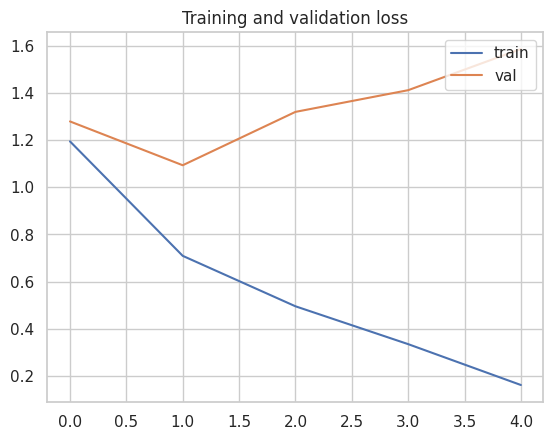

```python
epochs = range(len(history1.history['loss'])) # Get number of epochs

# plot loss learning curves
plt.plot  (epochs, history1.history['loss'], label = 'train')
plt.plot  (epochs, history1.history['val_loss'], label = 'val')
plt.legend(loc = 'upper right')
plt.title ('Training and validation loss')
```

The model is likely overfitting to the training data, failing to generalize to the validation set.

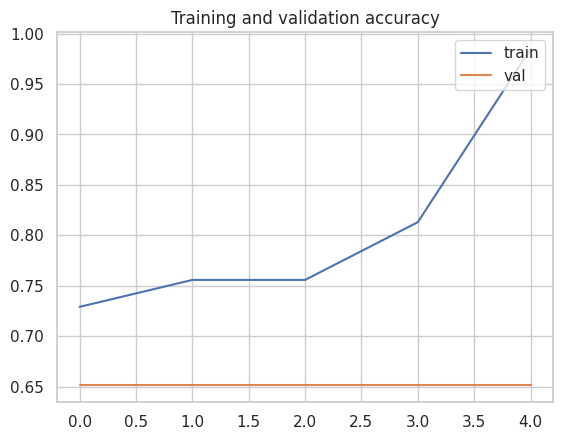

```python
epochs = range(len(history1.history['accuracy'])) # Get number of epochs

# plot loss learning curves
plt.plot  (epochs, history1.history['accuracy'], label = 'train')
plt.plot  (epochs, history1.history['val_accuracy'], label = 'val')
plt.legend(loc = 'upper right')
plt.title ('Training and validation accuracy')
```

step 2 :- LSTM classifier

```python
from tensorflow.keras.models import Sequential
from tensorflow.keras.layers import LSTM, Dense, Embedding
from tensorflow.keras.preprocessing.text import Tokenizer
from tensorflow.keras.preprocessing.sequence import pad_sequences
from sklearn.model_selection import train_test_split
```

```python
X_text = df['lemmatized_text']
y_text = df['Accident_Level']
```

```python
y_text = LabelEncoder().fit_transform(y_text)
```

```python
X_text_train, X_text_test, y_text_train, y_text_test = train_test_split(X_text, y_text, test_size = 0.20, random_state = 1, stratify = y_text)

print('X_text_train shape : ({0})'.format(X_text_train.shape[0]))
print('y_text_train shape : ({0},)'.format(y_text_train.shape[0]))
print('X_text_test shape : ({0})'.format(X_text_test.shape[0]))
print('y_text_test shape : ({0},)'.format(y_text_test.shape[0]))
```

```
X_text_train shape : (328)
y_text_train shape : (328,)
X_text_test shape : (83)
y_text_test shape : (83,)
```

```python
from tensorflow.keras.utils import to_categorical
y_text_train = to_categorical(y_text_train)
y_text_test =  to_categorical(y_text_test)
```

```python
tokenizer = Tokenizer(num_words=5000)
tokenizer.fit_on_texts(X_text_train)

X_text_train = tokenizer.texts_to_sequences(X_text_train)
X_text_test = tokenizer.texts_to_sequences(X_text_test)
```

```python
vocab_size = len(tokenizer.word_index) + 1
print("vocab_size:", vocab_size)

maxlen = 100

X_text_train = pad_sequences(X_text_train, padding='post', maxlen=maxlen)
X_text_test = pad_sequences(X_text_test, padding='post', maxlen=maxlen)
```

```
vocab_size: 2297
```